# R Notebook

## Исследовательское задание на экзамен по дисциплине Временные ряды

Анализ и прогноз валютного курса Австралийского доллара($AUS) к доллару США($USD)

ПУНКТ 1

```
[1] 1978    2
```

```
[1] 2021   10
```

## Нормализация данных

Посмотрим на график обменного курса AUS-USA.

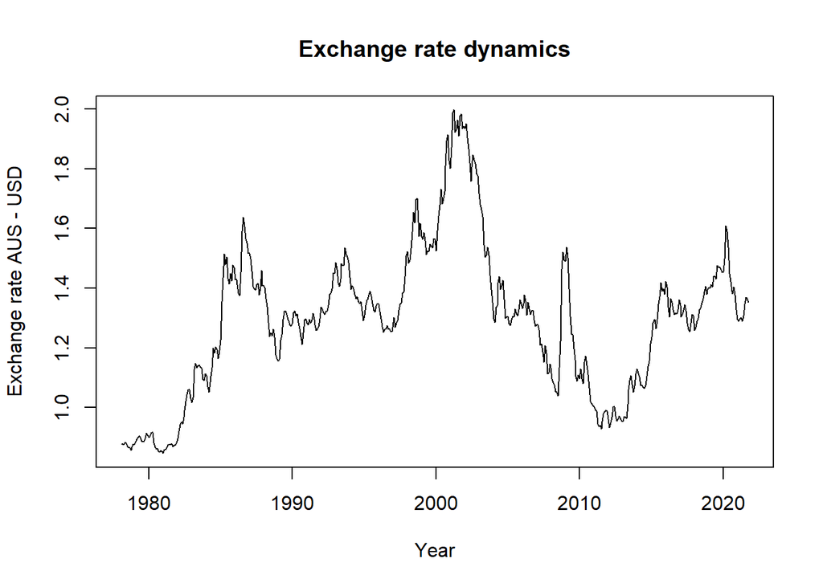

Обменный курс не выглядит стационарным. Проведем тест:

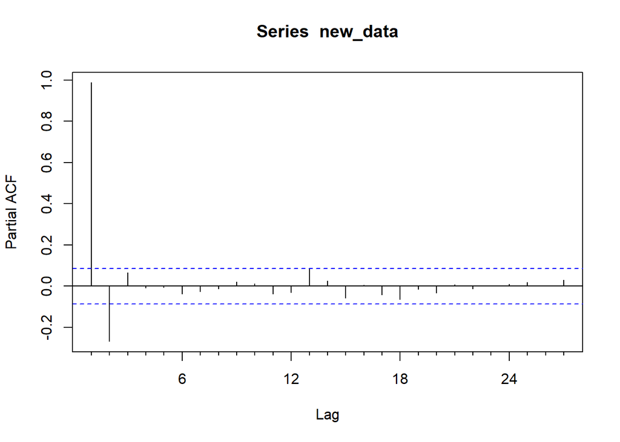

```
    Augmented Dickey-Fuller Test

data:  new_data
Dickey-Fuller = -2.4001, Lag order = 8, p-value = 0.409
alternative hypothesis: stationary
```

```
    KPSS Test for Level Stationarity

data:  new_data
KPSS Level = 1.0647, Truncation lag parameter = 6, p-value = 0.01
```

Мы провели тест на стационарность Augmented Dickey-Fuller. Вероятность, что такое распределение является нестационарным высока - 0.4, поэтому мы не отвергаем нулевую гипотезу. Ряд нестационарен

Проверим на первых разностях:

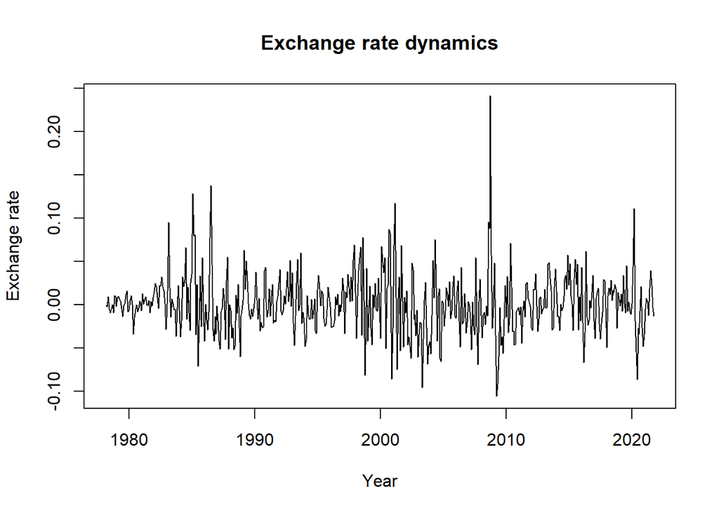

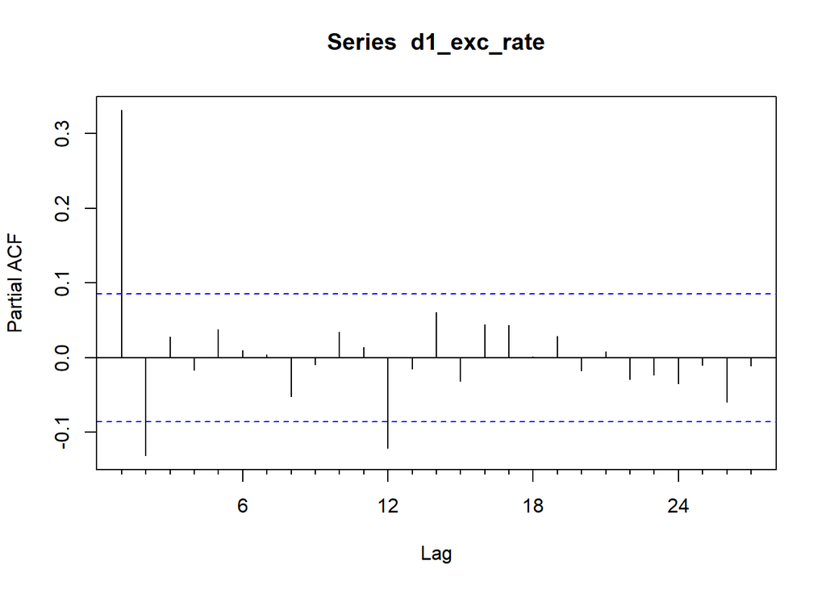

```
    Augmented Dickey-Fuller Test

data:  d1_exc_rate
Dickey-Fuller = -7.5464, Lag order = 8, p-value = 0.01
alternative hypothesis: stationary
```

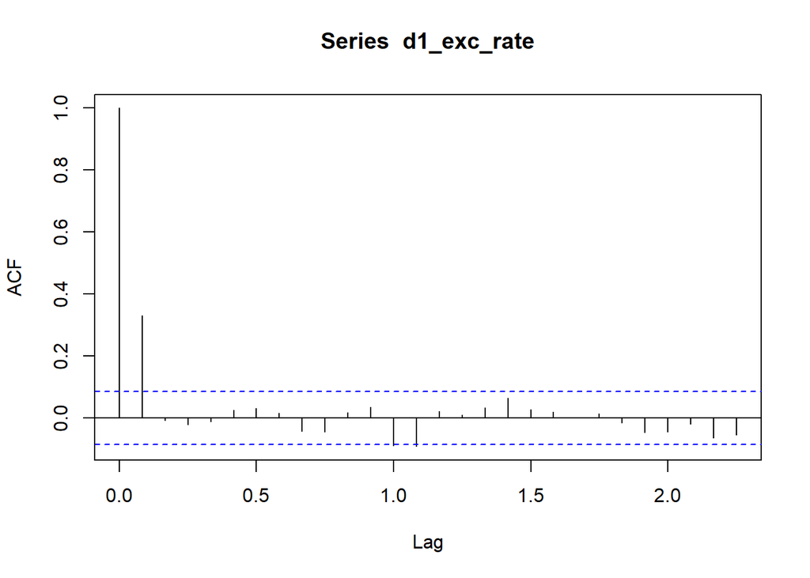

Рассмотрим для начала разные модели AR

```
[1] "AR1"
```

```
Series: d1_exc_rate
ARIMA(1,0,0) with non-zero mean

Coefficients:
         ar1    mean
      0.3302  0.0009
s.e.  0.0412  0.0021

sigma^2 = 0.001075:  log likelihood = 1048.37
AIC=-2090.73   AICc=-2090.68   BIC=-2077.95

Training set error measures:
                        ME       RMSE        MAE      MPE     MAPE      MASE
Training set -5.616198e-06 0.03272076 0.02397271 124.3462 168.0836 0.6369355
                   ACF1
Training set 0.04387051
```

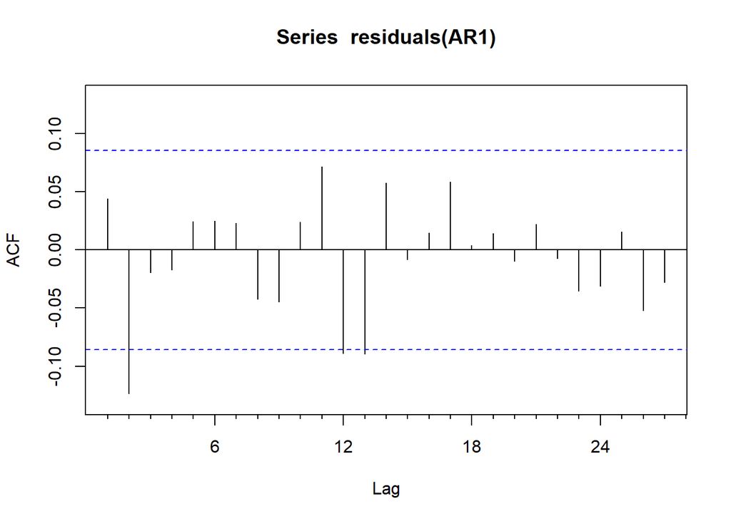

```
[1] 0.07388346
```

Есть автокорелляция в остатках

```
[1] "вариант 2. через функцию Arima пакета Forecast"
```

```
[1] "AR2"
```

[output not shown]

[figure not shown]

```
[1] 0.03962501
```

Есть автокорелляция в остатках

```
[1] "вариант 2. через функцию Arima пакета Forecast"
```

```
[1] "AR12"
```

```
Series: d1_exc_rate
ARIMA(12,0,0) with non-zero mean

Coefficients:
         ar1      ar2     ar3      ar4     ar5     ar6     ar7      ar8
      0.3791  -0.1380  0.0381  -0.0363  0.0377  0.0024  0.0256  -0.0476
s.e.  0.0433   0.0463  0.0466   0.0467  0.0466  0.0466  0.0465   0.0465
          ar9    ar10   ar11     ar12    mean
      -0.0147  0.0120  0.059  -0.1196  0.0009
s.e.   0.0464  0.0464  0.046   0.0431  0.0018

sigma^2 = 0.001056:  log likelihood = 1058.45
AIC=-2088.91   AICc=-2088.08   BIC=-2029.25

Training set error measures:
                        ME       RMSE       MAE      MPE     MAPE      MASE
Training set -1.415594e-06 0.03208894 0.0233153 132.6324 181.4748 0.6194686
                     ACF1
Training set -0.001136531
```

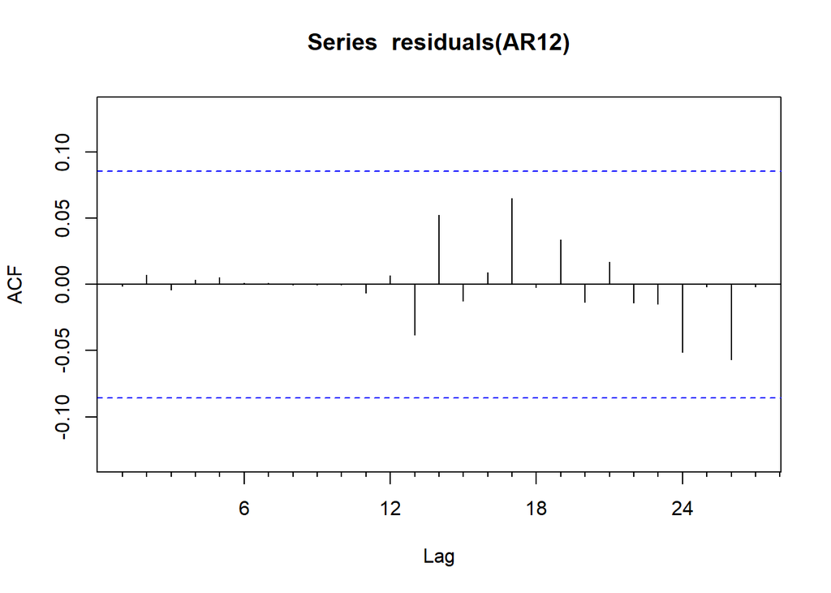

```
[1] NaN
```

Нет автокорелляции в остатках

Среди AR моделей самой подходящей оказалась модель AR(12)

MA

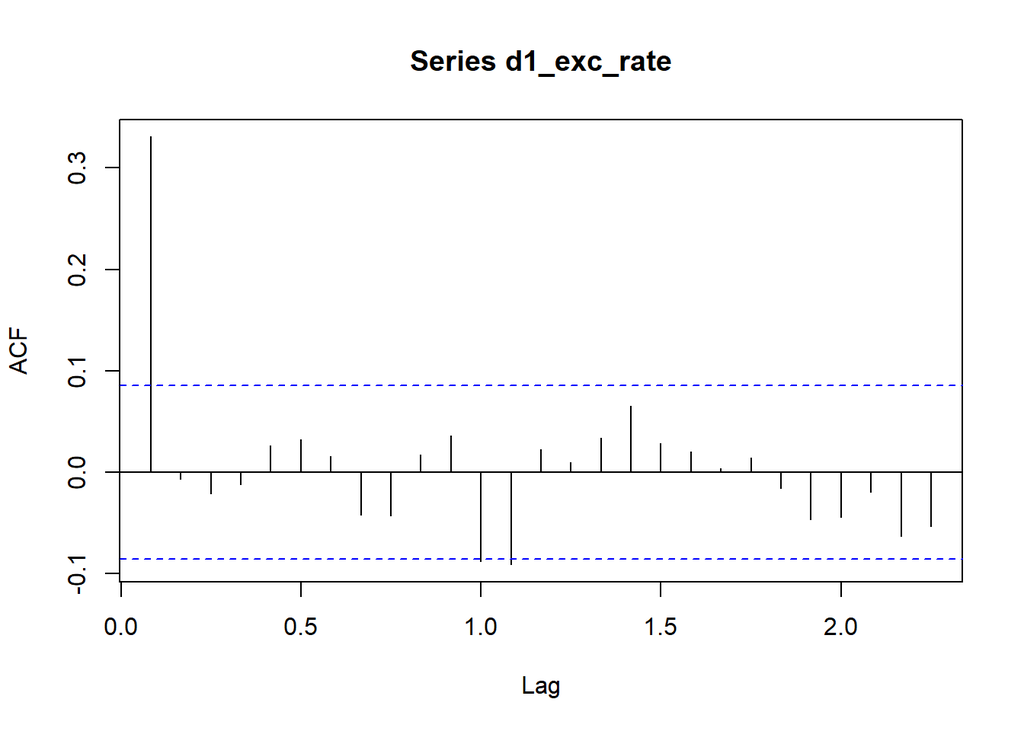

```
Series: data[, 2]
ARIMA(0,1,1) with drift

Coefficients:
         ma1  drift
      0.3782  9e-04
s.e.  0.0405  2e-03

sigma^2 = 0.001055:  log likelihood = 1053.15
AIC=-2100.3   AICc=-2100.25   BIC=-2087.51

Training set error measures:
                        ME      RMSE        MAE         MPE    MAPE      MASE
Training set -1.148988e-06 0.0323914 0.02356179 -0.01012133 1.75703 0.2008557
                     ACF1
Training set 0.0009212042
```

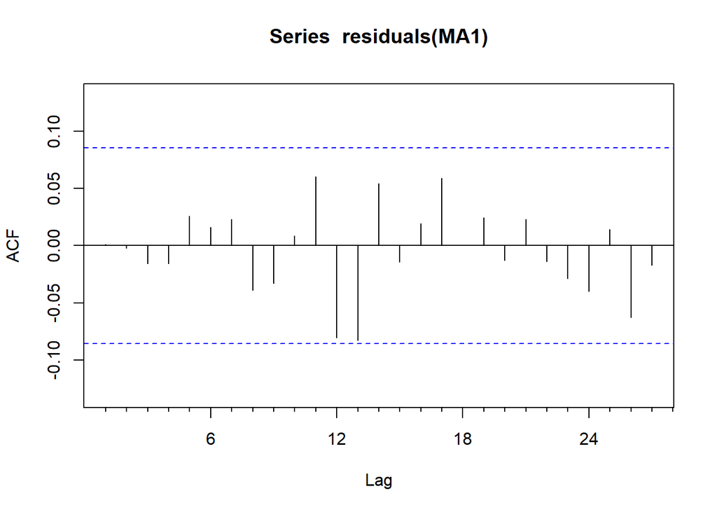

```
[1] 0.9803216
```

Автокорреляции в остатках нет

```
Series: data[, 2]
ARIMA(0,1,2) with drift

Coefficients:
         ma1     ma2  drift
      0.3784  0.0006  9e-04
s.e.  0.0438  0.0450  2e-03

sigma^2 = 0.001057:  log likelihood = 1053.15
AIC=-2098.3   AICc=-2098.22   BIC=-2081.25

Training set error measures:
                        ME      RMSE        MAE        MPE     MAPE      MASE
Training set -6.397493e-07 0.0323914 0.02356308 -0.0100618 1.757117 0.2008667
                     ACF1
Training set 0.0007101787
```

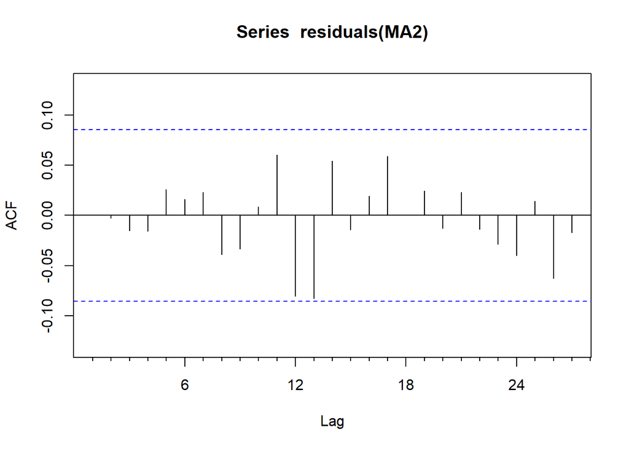

Автокорреляции в остатках нет

Проверим теперь модели ARMA

```
AR/MA
  0 1 2 3 4 5 6 7 8 9 10 11 12 13
0 x o o o o o o o o o o  o  x  o
1 x x o o o o o o o o o  x  x  o
2 x x x o o o o o o o o  o  o  o
3 x o x o o o o o o o o  o  o  o
4 x x x x o o o o o o o  o  o  o
5 x o x x o o o o o o o  o  o  o
6 x o x x o o o o o o o  o  o  o
7 o x x x x o o o o o o  o  o  o
```

Проверим модели ARMA(1,2) и ARMA(3,1)

```
Series: data[, 2]
ARIMA(1,1,2) with drift

Coefficients:
         ar1     ma1      ma2   drift
      0.1750  0.2021  -0.0675  0.0009
s.e.  7.5342  7.5748   2.9473  0.0019

sigma^2 = 0.001059:  log likelihood = 1053.15
AIC=-2096.3   AICc=-2096.18   BIC=-2074.99

Training set error measures:
                       ME      RMSE        MAE         MPE     MAPE      MASE
Training set -7.41285e-07 0.0323914 0.02355814 -0.01016071 1.756793 0.2008246
                    ACF1
Training set 0.002087015
```

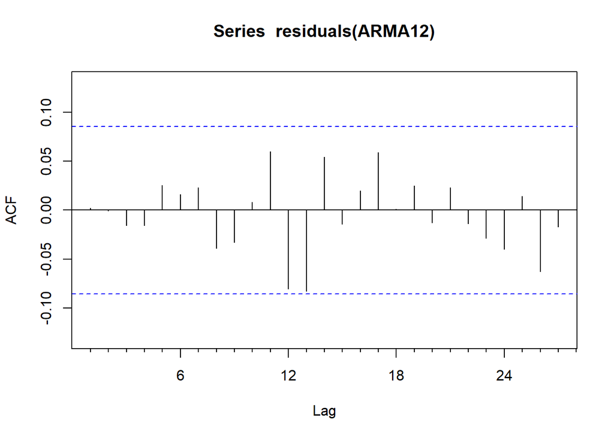

```
[1] 0.8622184
```

Автокорреляции в остатках нет

```
Series: data[, 2]
ARIMA(3,1,1) with drift

Coefficients:
          ar1     ar2      ar3     ma1   drift
      -0.6141  0.2360  -0.1198  1.0000  0.0009
s.e.   0.0434  0.0499   0.0433  0.0057  0.0019

sigma^2 = 0.001051:  log likelihood = 1054.75
AIC=-2097.49   AICc=-2097.33   BIC=-2071.92

Training set error measures:
                        ME       RMSE        MAE         MPE     MAPE      MASE
Training set -2.205081e-05 0.03223615 0.02349743 -0.01275315 1.753283 0.2003071
                    ACF1
Training set 0.002494735
```

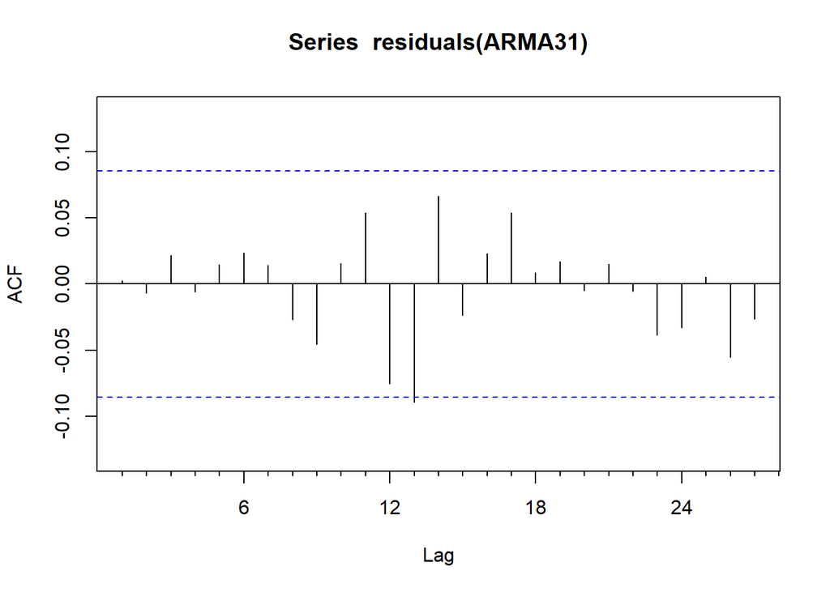

```
[1] 0.7034313
```

Автокорреляции в остатках почти нет (на графике ACF выпирает 13 период)

Посмотрим на параметры моделей, чтобы выбрать лучшую

|  | loglike | AIC | BIC |
| --- | --- | --- | --- |
| AR12 | 1058.455 | -2088.910 | -2029.249 |
| MA1 | 1053.148 | -2100.295 | -2087.511 |
| MA2 | 1053.148 | -2098.296 | -2081.250 |
| ARMA12 | 1053.148 | -2096.296 | -2074.989 |
| ARMA31 | 1054.747 | -2097.493 | -2071.924 |

Сделаем прогноз по этим моделям

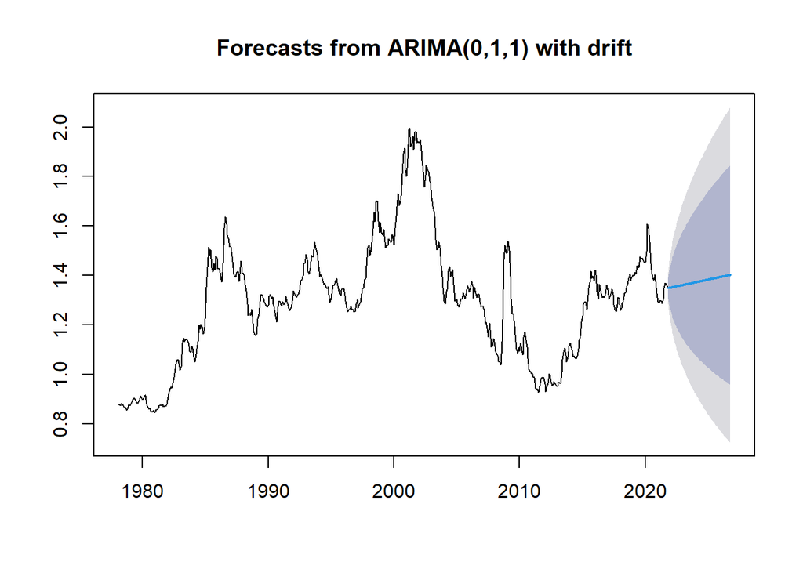

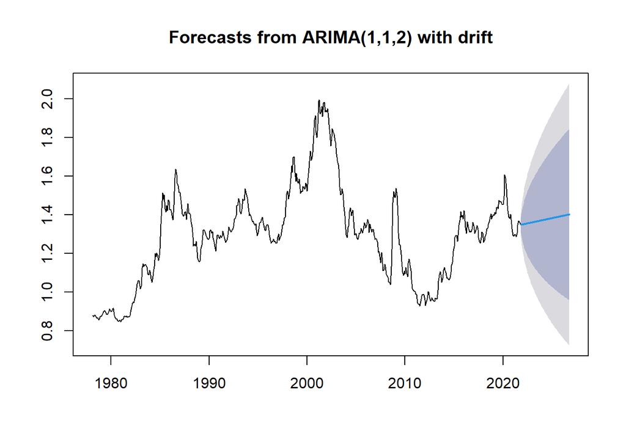

Проверим модели на наличие автокорреляции в квадратах остатков (arch-эффект)

```
    Box-Ljung test

data:  residuals(MA1)^2
X-squared = 32.364, df = 5, p-value = 5.032e-06
```

```
    Shapiro-Wilk normality test

data:  d1_exc_rate
W = 0.95097, p-value = 3.597e-12
```

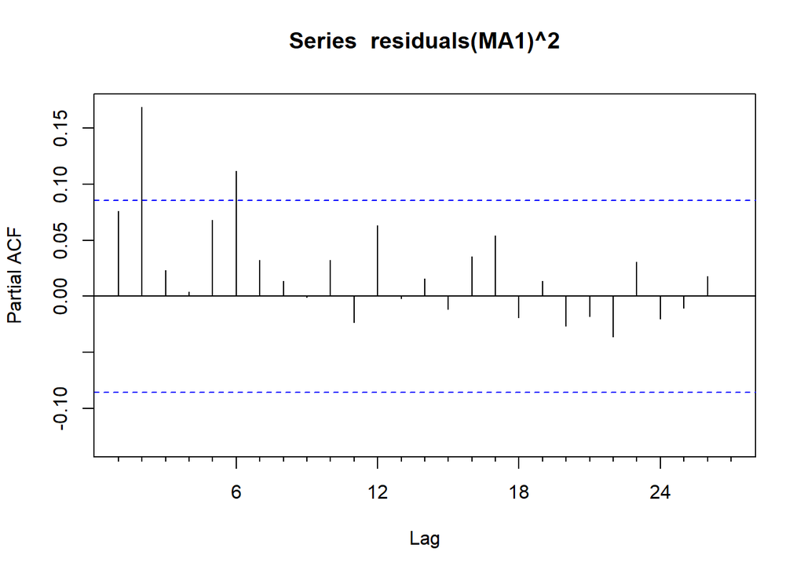

```
    Box-Ljung test

data:  residuals(ARMA12)^2
X-squared = 32.23, df = 3, p-value = 4.681e-07
```

```
    Shapiro-Wilk normality test

data:  d1_exc_rate
W = 0.95097, p-value = 3.597e-12
```

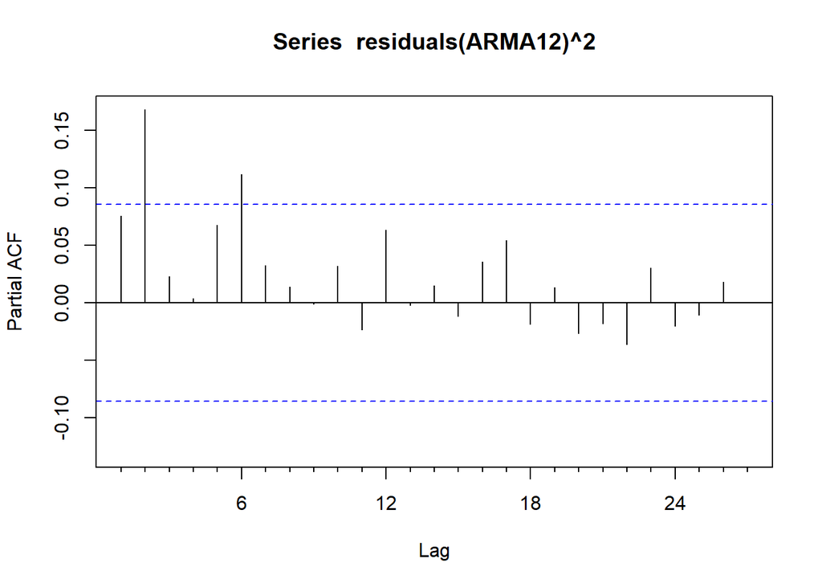

Для модели ARMA(1,2) попробуем модели GARCH[2], GARCH[6]

```
AR/MA
  0 1 2 3 4 5 6 7 8 9 10 11 12 13
0 o x o o o x o o o o o  x  o  o
1 x x o o o o o o o o o  x  o  o
2 x o o o o o o o o o o  o  o  o
3 x o x o o o o o o o o  o  o  o
4 o x o x o o o o o o o  o  o  o
5 x x x x x o o o o o o  o  o  o
6 x o o x x o o o o o o  o  o  o
7 x x o x o x o o o o o  o  o  o
```

```
           mu           ar1           ma1           ma2         omega
 0.0009000697  0.3784906177  0.0107399754 -0.2063873568  0.0000395053
       alpha1        alpha2         beta1         beta2         shape
 0.1441622962  0.1729313328  0.2861292840  0.3957770857  7.0266841572
```

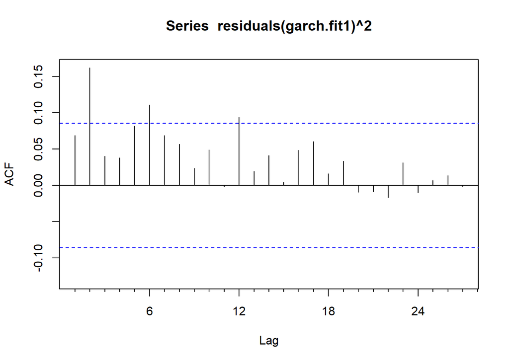

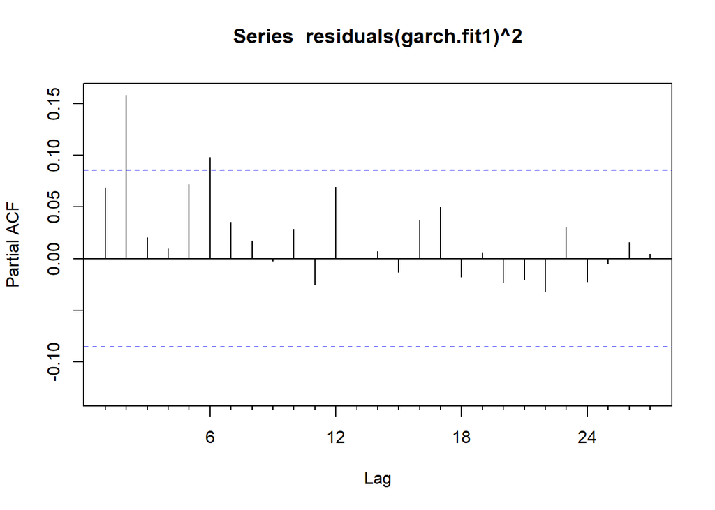

```
    Box-Ljung test

data:  residuals(garch.fit1)^2
X-squared = 28.107, df = 3, p-value = 3.448e-06
```

Составим прогноз, учитывая garch-эффект

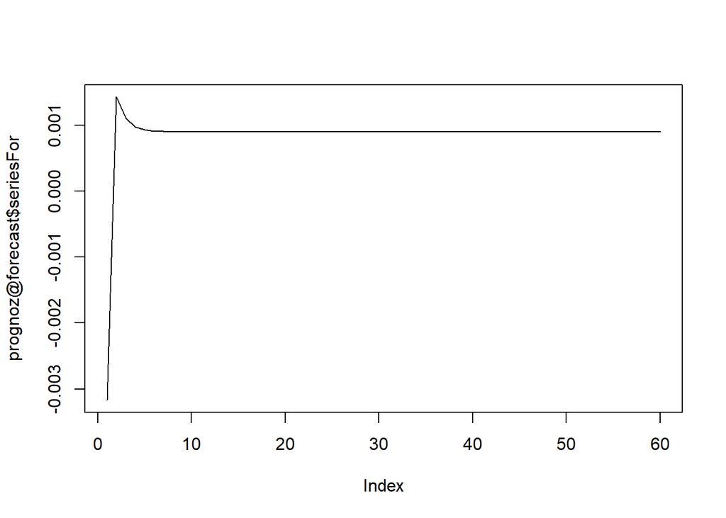

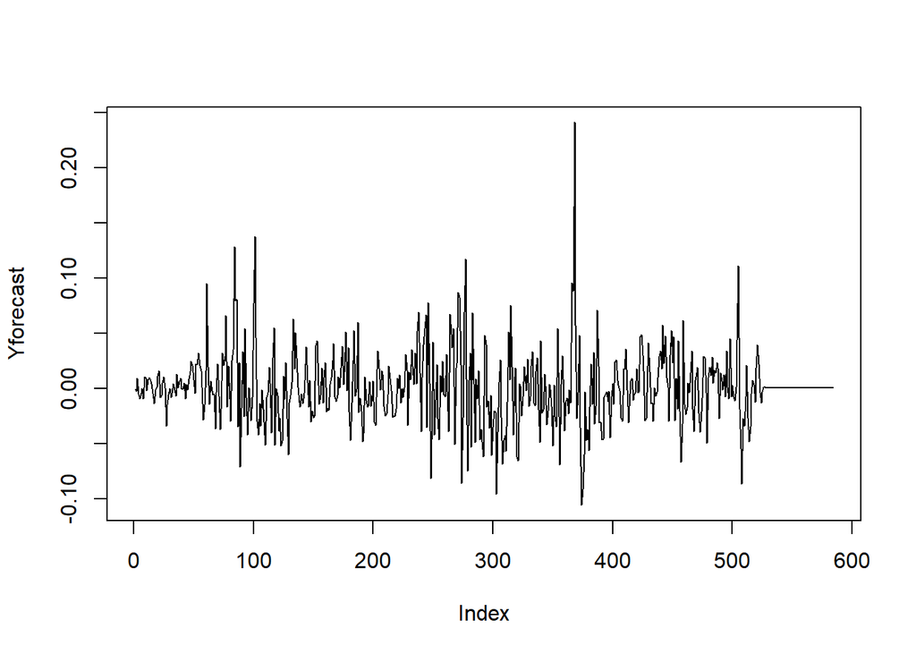

Начнём искать структурные разрывы

За долгосрочный прогноз отвечает коэффициент а0. Важно наличие структурного разрыва в интерсепте (коэффициенте а0). У нас достаточно большая выборка, поэтому мы для поиска структурных разрывов проверяем Sup-F тест.

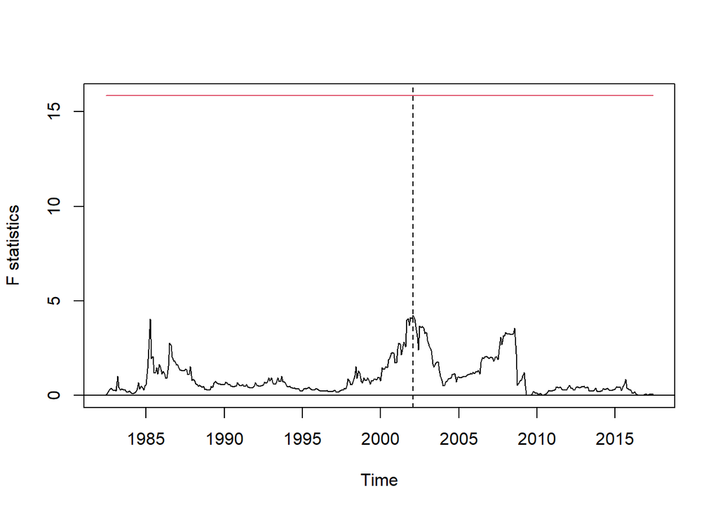

```
[1] 288
```

```
    supF test

data:  stat
sup.F = 4.2454, p-value = 0.7568
```

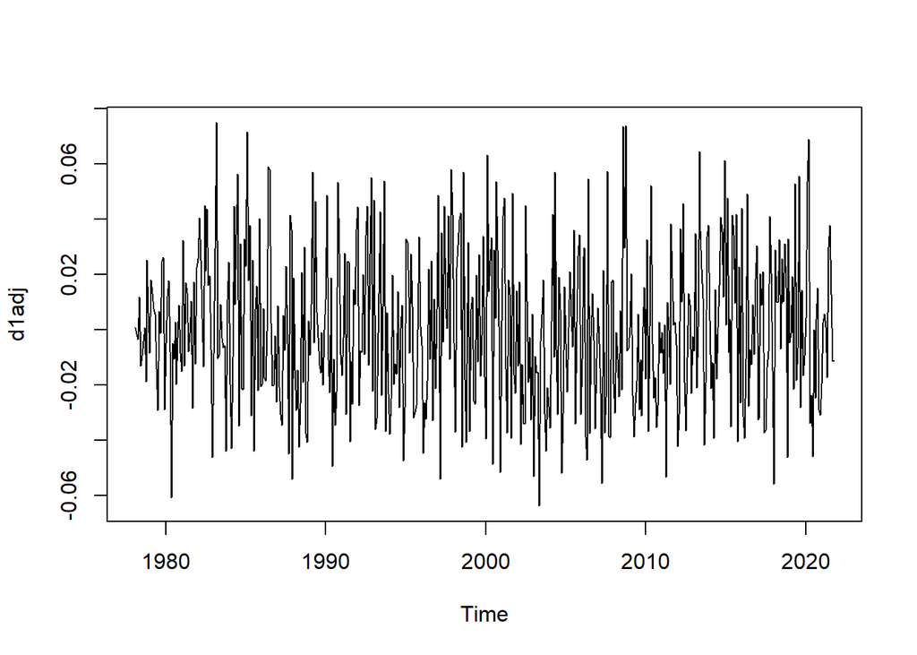

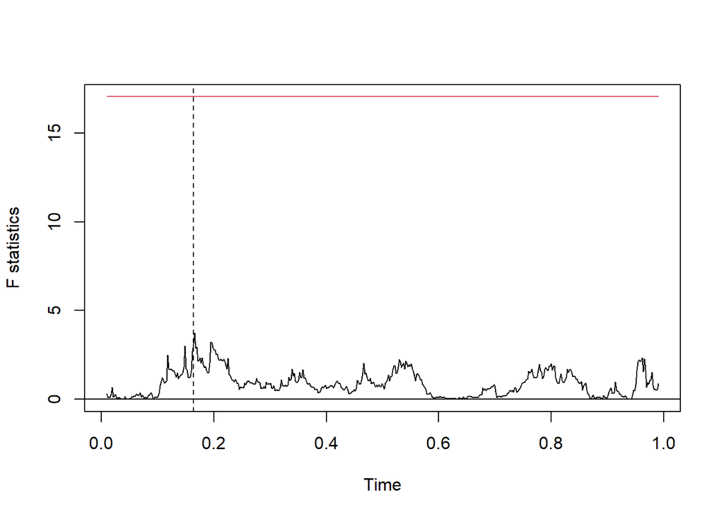

```
[1] 87
```

```
    supF test

data:  stat
sup.F = 3.7258, p-value = 0.9729
```

Sup-F тест показывает, что структурных разрывов нет.

Попробуем найти разрывы методом CUSUM

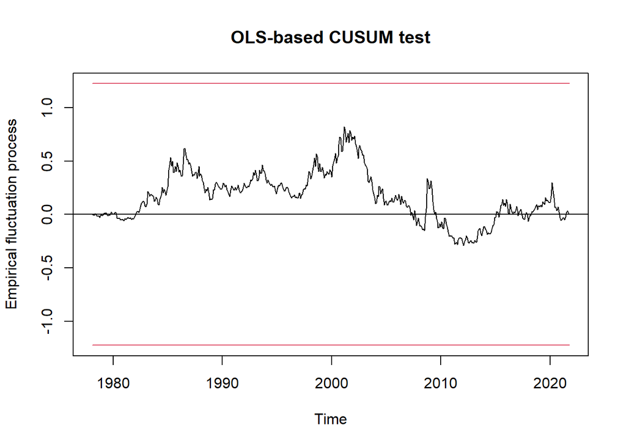

```
    OLS-based CUSUM test

data:  stat
S0 = 0.82084, p-value = 0.5106
```

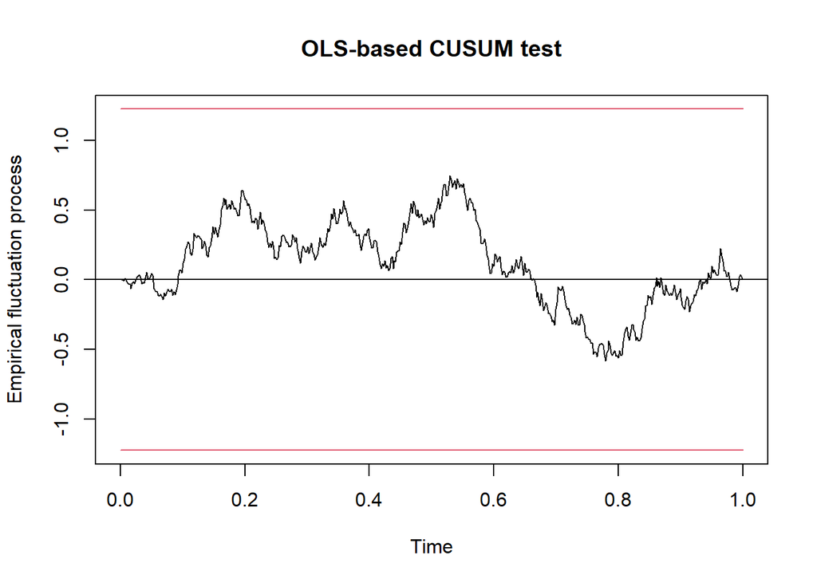

```
    OLS-based CUSUM test

data:  stat
S0 = 0.74444, p-value = 0.6365
```

Структурных разрывов нет

## VAR-модель

Посмотрим на графики прочих переменных:

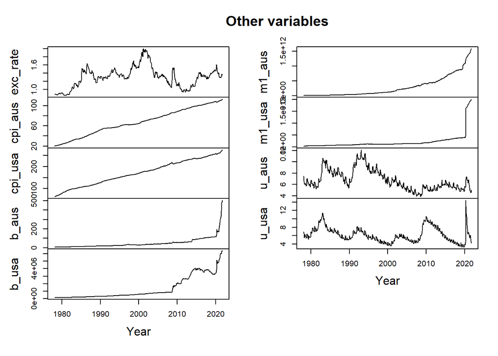

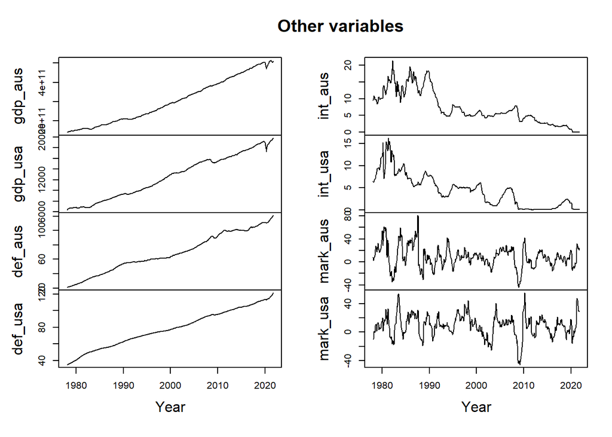

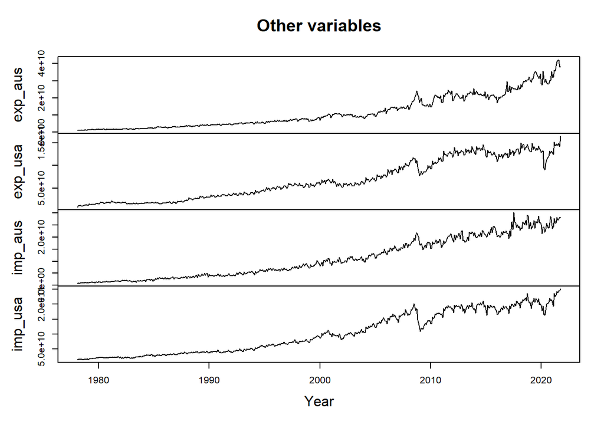

Займемся нормализацией переменных. Переменные 5,6,7,8,19,20,21,22 - нужно логарифмировать. Явно прослеживается экспоненциальный тренд.

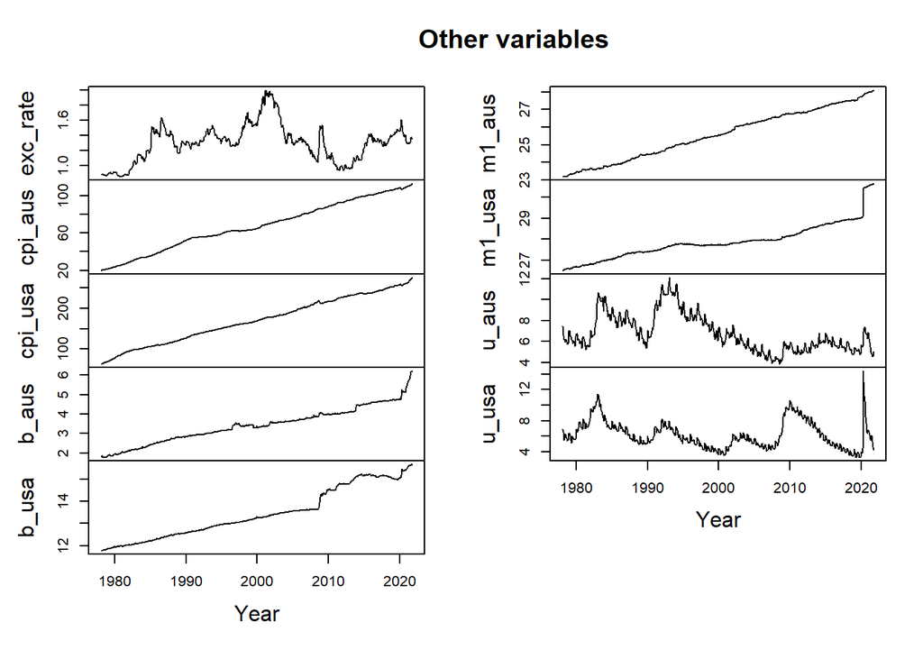

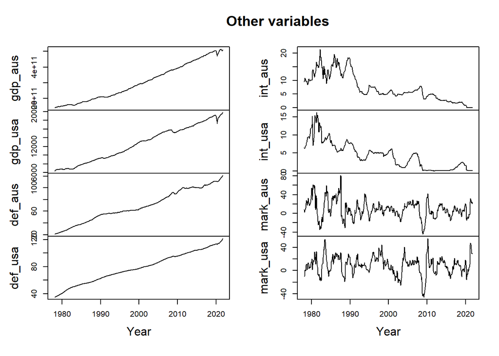

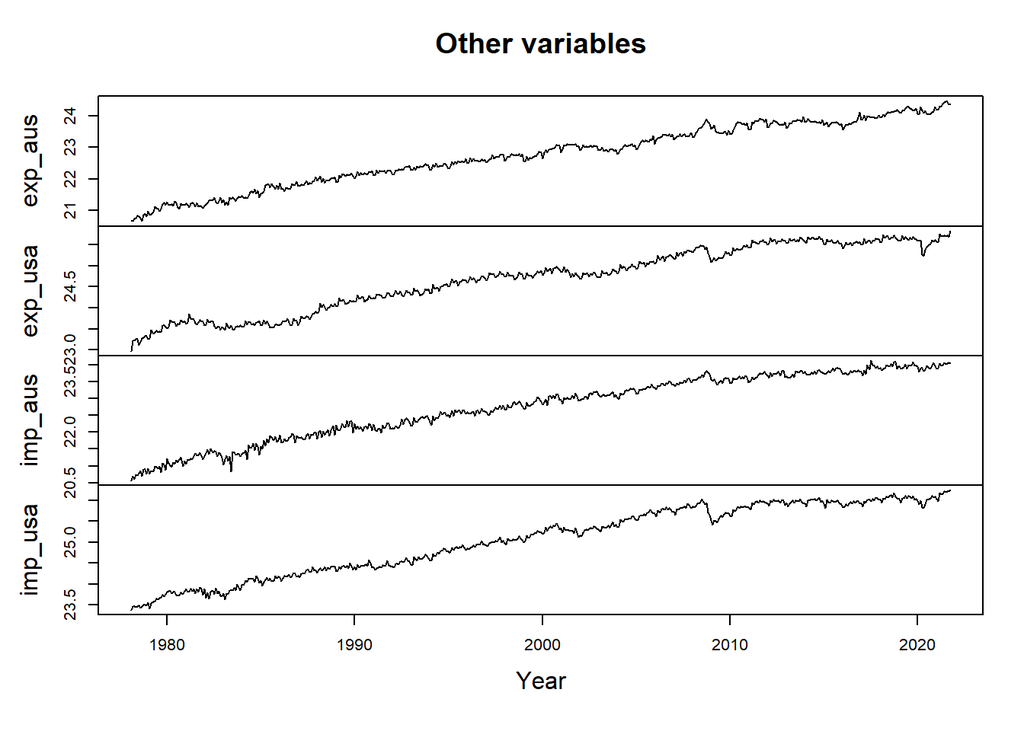

Проверим, какие из рядов являются стационарными.

```
 [1] 0.40896718 0.51575053 0.06760807 0.99000000 0.69891684 0.51718757
 [7] 0.99000000 0.29595425 0.16426778 0.48478288 0.08120415 0.76805548
[13] 0.63310878 0.06005052 0.05432413 0.01000000 0.01000000 0.01146369
[19] 0.37396909 0.50648295 0.53869804
```

```
 [1] FALSE FALSE FALSE FALSE FALSE FALSE FALSE FALSE FALSE FALSE FALSE FALSE
[13] FALSE FALSE FALSE  TRUE  TRUE  TRUE FALSE FALSE FALSE
```

```
 [1] 0.0100000 0.0100000 0.0100000 0.0100000 0.0100000 0.0100000 0.0100000
 [8] 0.0100000 0.0100000 0.0100000 0.0100000 0.0100000 0.9333169 0.0100000
[15] 0.0100000 0.0100000 0.0100000 0.0100000 0.0100000 0.0100000 0.0100000
```

```
 [1]  TRUE  TRUE  TRUE  TRUE  TRUE  TRUE  TRUE  TRUE  TRUE  TRUE  TRUE  TRUE
[13] FALSE  TRUE  TRUE  TRUE  TRUE  TRUE  TRUE  TRUE  TRUE
```

Одна переменная все равно не стационарна, поэтому перейдем ко 2-м разностям:

```
 [1] 0.01 0.01 0.01 0.01 0.01 0.01 0.01 0.01 0.01 0.01 0.01 0.01 0.01 0.01 0.01
[16] 0.01 0.01 0.01 0.01 0.01 0.01
```

```
 [1] TRUE TRUE TRUE TRUE TRUE TRUE TRUE TRUE TRUE TRUE TRUE TRUE TRUE TRUE TRUE
[16] TRUE TRUE TRUE TRUE TRUE TRUE
```

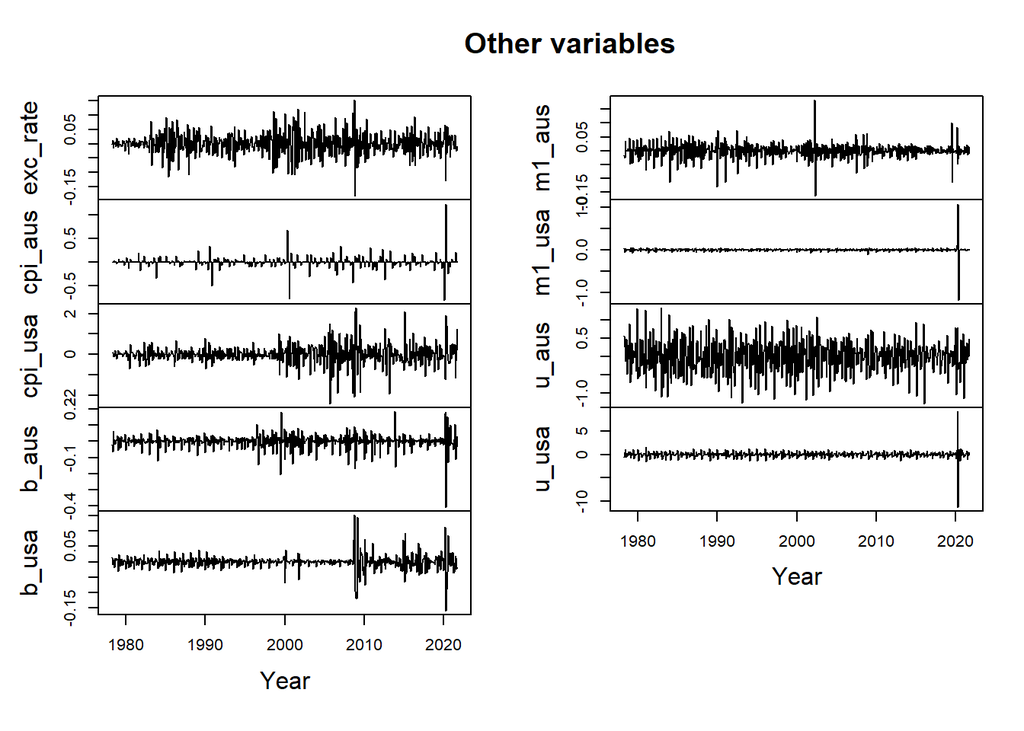

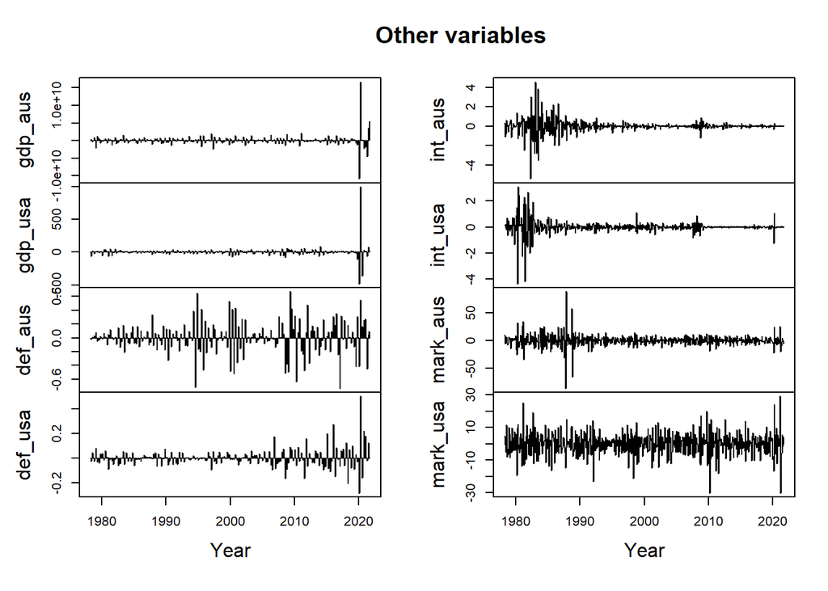

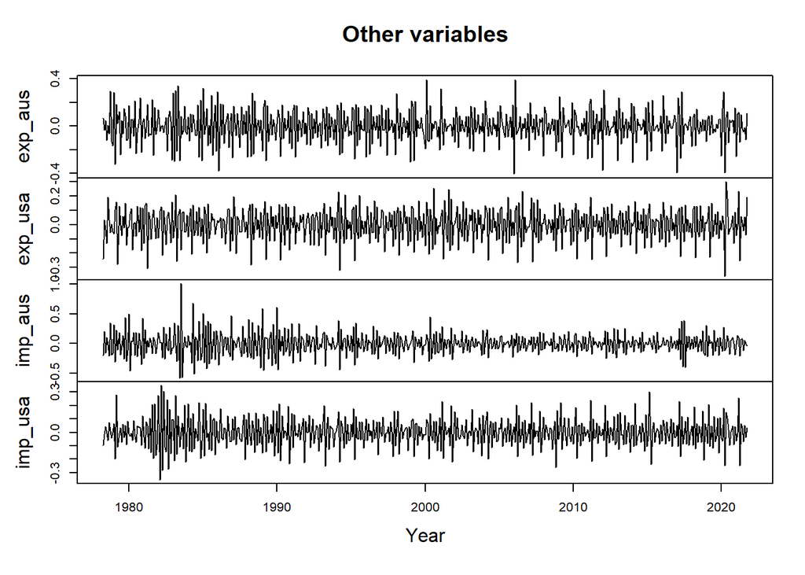

Теперь все временные ряды стационарны, можно с ними работать дальше.

Далее нужно использовать только вторые разности из датасета data_norm.

Чтобы найти переменные, влияющие на обменный курс, проведем тест Грэнджера на причинность:

Инфляция в Австралии оказывает влияние на обменный курс $AU-$US на 5%-ном уровне значимости.

| номер_переменной | переменная | p_value | значимость |
| --- | --- | --- | --- |
| 3 | cpi_aus | 0.030804495 | FALSE |
| 4 | cpi_usa | 0.076917405 | FALSE |
| 5 | b_aus | 0.255800907 | FALSE |
| 6 | b_usa | 0.130137487 | FALSE |
| 7 | m1_aus | 0.115028002 | FALSE |
| 8 | m1_usa | 0.203471917 | FALSE |
| 9 | u_aus | 0.296420185 | FALSE |
| 10 | u_usa | 0.955999390 | FALSE |
| 11 | gdp_aus | 0.933601468 | FALSE |
| 12 | gdp_usa | 0.598878400 | FALSE |

[output cut: 10 more lines]

При включении в модель по отдельности некоторые переменные, а именно: - дефлятор ВВП Австралии, (<0.01) - дефлятор ВВП США,(<0.05) - уровень цен в Австралии, (<0.05) - уровень цен в США, (<0.1) - объем экспорта СШA (<0.1) уменьшают ошибку прогноза и следовательно улучшают предсказание обменного курса $AU-$US.

Прочие переменные, а именно: уровень цен в США, денежные аггрегаты, безработица, ВВП, %-ная ставка, индекс рынка, импорт и экспорт в обеих странах - не оказывают статистически значимого влияния на обменный курс на 5%-ном уровне значимости.

Так, например, выглядят кросс-корреляционная функция для обменного курса и самой значимой переменной - дефлятора ВВП Австралии:

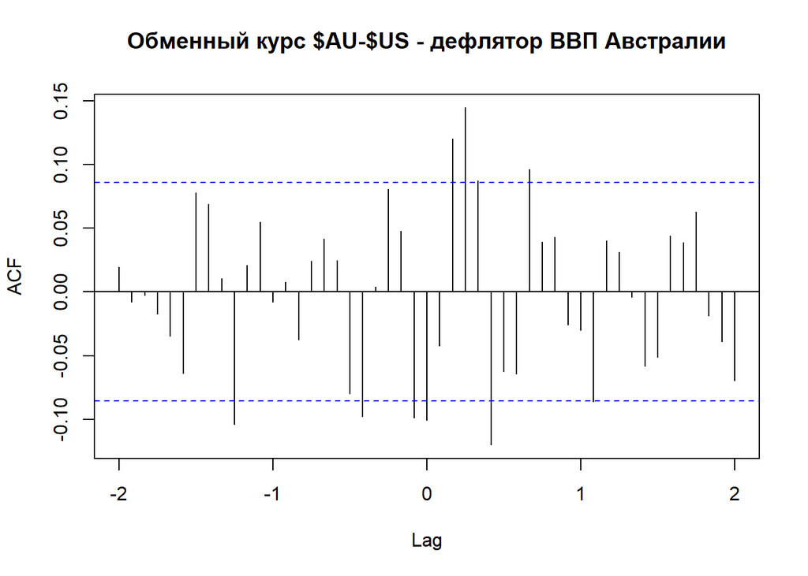

```
$selection
AIC(n)  HQ(n)  SC(n) FPE(n)
    15     12      4     15

$criteria
                   1             2             3             4             5
AIC(n) -1.037232e+01 -1.048192e+01 -1.068665e+01 -1.074112e+01 -1.075654e+01
HQ(n)  -1.035218e+01 -1.044836e+01 -1.063966e+01 -1.068071e+01 -1.068270e+01
SC(n)  -1.032104e+01 -1.039645e+01 -1.056700e+01 -1.058728e+01 -1.056851e+01
FPE(n)  3.128661e-05  2.803888e-05  2.284798e-05  2.163683e-05  2.130588e-05
                   6             7             8             9            10
AIC(n) -1.078050e+01 -1.077532e+01 -10.782634367 -1.080583e+01 -1.081745e+01
HQ(n)  -1.069323e+01 -1.067463e+01 -10.668519620 -1.067829e+01 -1.067649e+01
SC(n)  -1.055828e+01 -1.051892e+01 -10.492045568 -1.048105e+01 -1.045849e+01
FPE(n)  2.080175e-05  2.091003e-05   0.000020758  2.028256e-05  2.004864e-05
                  11            12            13            14            15
AIC(n) -1.081705e+01 -1.091716e+01 -1.092135e+01 -1.090788e+01 -1.094071e+01
HQ(n)  -1.066266e+01 -1.074934e+01 -1.074011e+01 -1.071321e+01 -1.073262e+01
SC(n)  -1.042390e+01 -1.048982e+01 -1.045982e+01 -1.041217e+01 -1.041082e+01
FPE(n)  2.005739e-05  1.814738e-05  1.807238e-05  1.831843e-05  1.772778e-05
                  16            17            18            19            20
AIC(n) -1.093719e+01 -1.092251e+01 -1.091836e+01 -1.090767e+01 -1.089429e+01
HQ(n)  -1.071567e+01 -1.068757e+01 -1.066999e+01 -1.064587e+01 -1.061907e+01
SC(n)  -1.037311e+01 -1.032424e+01 -1.028590e+01 -1.024102e+01 -1.019346e+01
FPE(n)  1.779159e-05  1.805609e-05  1.813288e-05  1.832953e-05  1.857838e-05
                  21            22            23            24            25
AIC(n) -1.093342e+01 -1.092144e+01 -1.090870e+01 -1.091294e+01 -1.089917e+01
HQ(n)  -1.064478e+01 -1.061937e+01 -1.059320e+01 -1.058402e+01 -1.055683e+01
SC(n)  -1.019840e+01 -1.015223e+01 -1.010530e+01 -1.007536e+01 -1.002740e+01
FPE(n)  1.786762e-05  1.808541e-05  1.831995e-05  1.824528e-05  1.850134e-05
                  26            27            28            29            30
AIC(n) -1.088830e+01 -1.092888e+01 -1.092788e+01 -1.091216e+01 -1.090211e+01
HQ(n)  -1.053253e+01 -1.055968e+01 -1.054526e+01 -1.051611e+01 -1.049264e+01
SC(n)  -9.982345e+00 -9.988736e+00 -9.953554e+00 -9.903641e+00 -9.859411e+00
FPE(n)  1.870706e-05  1.796674e-05  1.798850e-05  1.827783e-05  1.846688e-05
                  31            32
AIC(n) -1.089385e+01 -1.088076e+01
HQ(n)  -1.047095e+01 -1.044444e+01
SC(n)  -9.816958e+00 -9.769690e+00
FPE(n)  1.862509e-05  1.887564e-05
```

Рекоммендуется брать 15 лагов

```
VAR Estimation Results:
=========================
Endogenous variables: exc_rate, def_aus
Deterministic variables: const
Sample size: 495
Log Likelihood: 1418.519
Roots of the characteristic polynomial:
0.9705 0.9705 0.9699 0.9699 0.9685 0.9685 0.9665 0.9665 0.9631 0.9631 0.9606 0.9606 0.9542 0.9542 0.9535 0.9535 0.9532 0.9529 0.9529 0.9527 0.9527 0.945 0.945 0.9441 0.9441 0.9428 0.9428 0.9386 0.9386 0.9314 0.9314 0.9299 0.9299 0.9273 0.9273 0.9229 0.9229 0.9219 0.9219 0.9209 0.9209 0.9206 0.9206 0…
Call:
VAR(y = var1, p = 28, type = "const")


Estimation results for equation exc_rate:
=========================================
exc_rate = exc_rate.l1 + def_aus.l1 + exc_rate.l2 + def_aus.l2 + exc_rate.l3 + def_aus.l3 + exc_rate.l4 + def_aus.l4 + exc_rate.l5 + def_aus.l5 + exc_rate.l6 + def_aus.l6 + exc_rate.l7 + def_aus.l7 + exc_rate.l8 + def_aus.l8 + exc_rate.l9 + def_aus.l9 + exc_rate.l10 + def_aus.l10 + exc_rate.l11 + de…

               Estimate Std. Error t value Pr(>|t|)
exc_rate.l1  -0.6240883  0.0477485 -13.070  < 2e-16 ***
def_aus.l1   -0.0331418  0.0140999  -2.351 0.019190 *
exc_rate.l2  -0.7074314  0.0565129 -12.518  < 2e-16 ***
def_aus.l2    0.0017140  0.0138739   0.124 0.901733
exc_rate.l3  -0.5825549  0.0660976  -8.814  < 2e-16 ***
def_aus.l3    0.0412542  0.0138748   2.973 0.003109 **
exc_rate.l4  -0.5816245  0.0723201  -8.042 8.31e-15 ***
def_aus.l4    0.0263935  0.0162389   1.625 0.104813
exc_rate.l5  -0.5307040  0.0787514  -6.739 5.04e-11 ***
def_aus.l5    0.0052151  0.0159244   0.327 0.743451
exc_rate.l6  -0.5434960  0.0845810  -6.426 3.43e-10 ***
def_aus.l6    0.0199935  0.0158748   1.259 0.208539
exc_rate.l7  -0.4708705  0.0898831  -5.239 2.52e-07 ***
def_aus.l7   -0.0080739  0.0164028  -0.492 0.622803
exc_rate.l8  -0.4521072  0.0936716  -4.827 1.92e-06 ***
def_aus.l8    0.0180493  0.0157109   1.149 0.251249
exc_rate.l9  -0.3878713  0.0968959  -4.003 7.35e-05 ***
def_aus.l9    0.0268671  0.0159610   1.683 0.093031 .
exc_rate.l10 -0.3383824  0.0993014  -3.408 0.000716 ***
def_aus.l10   0.0140323  0.0174800   0.803 0.422549
exc_rate.l11 -0.2794364  0.1010299  -2.766 0.005917 **
def_aus.l11   0.0255143  0.0168450   1.515 0.130582
exc_rate.l12 -0.3769871  0.1019615  -3.697 0.000246 ***
```

[output cut: 109 more lines]

```
Residual standard error: 0.1134 on 438 degrees of freedom
Multiple R-Squared: 0.4175, Adjusted R-squared: 0.3431
F-statistic: 5.607 on 56 and 438 DF,  p-value: < 2.2e-16



Covariance matrix of residuals:
           exc_rate    def_aus
exc_rate  0.0011149 -0.0003649
def_aus  -0.0003649  0.0128530

Correlation matrix of residuals:
         exc_rate  def_aus
exc_rate  1.00000 -0.09638
def_aus  -0.09638  1.00000
```

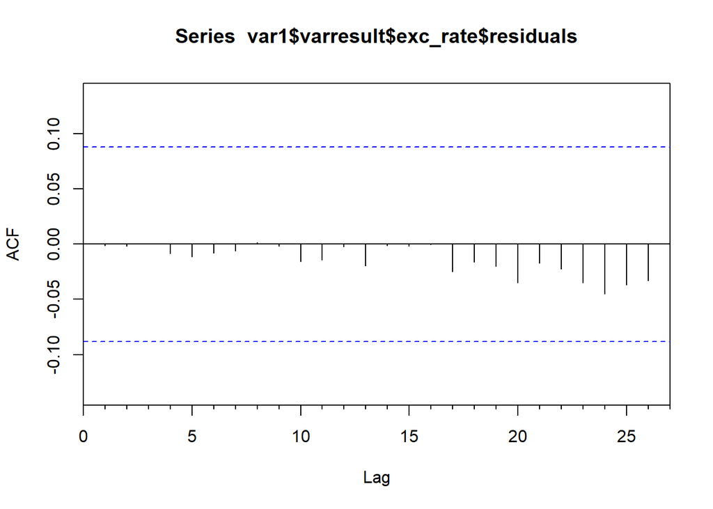

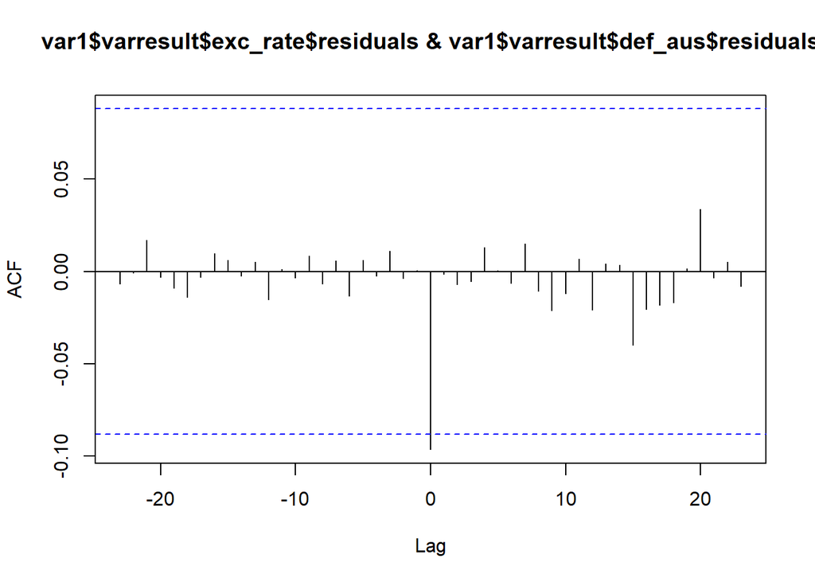

```
 lags statistic  df   p-value
   56  112.9419 112 0.4572786
```

```
 lags statistic  df   p-value
   56  116.6319 112 0.3632713
```